# NYPD Shooting Data Report

E. Benton

2/22/2022

### **Introduction**

This data breaks down every shooting that has happened in New York City from 2006 through the end of 2020. Shooting data contains information about the incident, location and time of occurrence, and victim/suspect demographics. Data is updated through end of the previous calendar year.

In this analysis I aim to determine if there is any significant or obvious relationship between shootings and the time of day in New York City.

**Reading in the Data**

```r
#First the data from the CSV file will be imported
library(tidyverse)
link_in <- 'https://data.cityofnewyork.us/api/views/833y-fsy8/rows.csv'
shooting_data <- read_csv(link_in)
summary(shooting_data)
```

```
##   INCIDENT_KEY        OCCUR_DATE         OCCUR_TIME           BORO
##  Min.   :  9953245   Length:23585       Length:23585      Length:23585
##  1st Qu.: 55322804   Class :character   Class1:hms        Class :character
##  Median : 83435362   Mode  :character   Class2:difftime   Mode  :character
##  Mean   :102280741                      Mode  :numeric
##  3rd Qu.:150911774
##  Max.   :230611229
##
##     PRECINCT      JURISDICTION_CODE LOCATION_DESC      STATISTICAL_MURDER_FLAG
##  Min.   :  1.00   Min.   :0.000     Length:23585       Mode :logical
##  1st Qu.: 44.00   1st Qu.:0.000     Class :character   FALSE:19085
##  Median : 69.00   Median :0.000     Mode  :character   TRUE :4500
##  Mean   : 66.21   Mean   :0.333
##  3rd Qu.: 81.00   3rd Qu.:0.000
##  Max.   :123.00   Max.   :2.000
##                   NA's   :2
##  PERP_AGE_GROUP       PERP_SEX          PERP_RACE         VIC_AGE_GROUP
##  Length:23585       Length:23585       Length:23585       Length:23585
##  Class :character   Class :character   Class :character   Class :character
##  Mode  :character   Mode  :character   Mode  :character   Mode  :character
##
##
##
##
##    VIC_SEX            VIC_RACE           X_COORD_CD        Y_COORD_CD
##  Length:23585       Length:23585       Min.   : 914928   Min.   :125757
##  Class :character   Class :character   1st Qu.: 999925   1st Qu.:182539
##  Mode  :character   Mode  :character   Median :1007654   Median :193470
##                                        Mean   :1009379   Mean   :207300
##                                        3rd Qu.:1016782   3rd Qu.:239163
##                                        Max.   :1066815   Max.   :271128
##
##     Latitude       Longitude        Lon_Lat
##  Min.   :40.51   Min.   :-74.25   Length:23585
##  1st Qu.:40.67   1st Qu.:-73.94   Class :character
##  Median :40.70   Median :-73.92   Mode  :character
##  Mean   :40.74   Mean   :-73.91
##  3rd Qu.:40.82   3rd Qu.:-73.88
##  Max.   :40.91   Max.   :-73.70
##
```

```r
head(shooting_data)
```

| INCIDENT_KEY | OCCUR_DATE | OCCUR_TIME | BORO | PRECINCT | JURISDICTION_CODE | LOCATION_DESC | STATISTICAL_MURDER_FLAG | PERP_AGE_GROUP | PERP_SEX | PERP_RACE | VIC_AGE_GROUP | VIC_SEX | VIC_RACE | X_COORD_CD | Y_COORD_CD | Latitude | Longitude | Lon_Lat |
| --- | --- | --- | --- | --- | --- | --- | --- | --- | --- | --- | --- | --- | --- | --- | --- | --- | --- | --- |
| 24050482 | 08/27/2006 | 05:35:00 | BRONX | 52 | 0 | NA | TRUE | NA | NA | NA | 25-44 | F | BLACK HISPANIC | 1017542 | 255918.9 | 40.86906 | -73.87963 | POINT (-73.87963173099996 40.86905819000003) |
| 77673979 | 03/11/2011 | 12:03:00 | QUEENS | 106 | 0 | NA | FALSE | NA | NA | NA | 65+ | M | WHITE | 1027543 | 186095.0 | 40.67737 | -73.84392 | POINT (-73.84392019199998 40.677366895000034) |
| 203350417 | 10/06/2019 | 01:09:00 | BROOKLYN | 77 | 0 | NA | FALSE | NA | NA | NA | 18-24 | F | BLACK | 995325 | 185155.0 | 40.67489 | -73.96008 | POINT (-73.96007501899999 40.674885741000026) |
| 80584527 | 09/04/2011 | 03:35:00 | BRONX | 40 | 0 | NA | FALSE | NA | NA | NA | <18 | M | BLACK | 1007453 | 233952.0 | 40.80880 | -73.91618 | POINT (-73.91618413199996 40.80879780500004) |
| 90843766 | 05/27/2013 | 21:16:00 | QUEENS | 100 | 0 | NA | FALSE | NA | NA | NA | 18-24 | M | BLACK | 1041267 | 157133.5 | 40.59780 | -73.79469 | POINT (-73.79468553799995 40.597796249000055) |
| 92393427 | 09/01/2013 | 04:17:00 | BROOKLYN | 67 | 0 | NA | FALSE | NA | NA | NA | <18 | M | BLACK | 1001694 | 170112.9 | 40.63359 | -73.93715 | POINT (-73.93715330699996 40.63358818100005) |

**Tidying the Data**

```r
##Removing columns not need for my analysis
shooting_data <- shooting_data %>%
select(-c(INCIDENT_KEY, PRECINCT, JURISDICTION_CODE, PERP_AGE_GROUP, PERP_SEX,
PERP_RACE, VIC_AGE_GROUP, VIC_SEX, VIC_RACE, X_COORD_CD, Y_COORD_CD,
Latitude, Longitude, Lon_Lat))
shooting_data
```

| OCCUR_DATE | OCCUR_TIME | BORO | LOCATION_DESC | STATISTICAL_MURDER_FLAG |
| --- | --- | --- | --- | --- |
| 08/27/2006 | 05:35:00 | BRONX | NA | TRUE |
| 03/11/2011 | 12:03:00 | QUEENS | NA | FALSE |
| 10/06/2019 | 01:09:00 | BROOKLYN | NA | FALSE |
| 09/04/2011 | 03:35:00 | BRONX | NA | FALSE |
| 05/27/2013 | 21:16:00 | QUEENS | NA | FALSE |
| 09/01/2013 | 04:17:00 | BROOKLYN | NA | FALSE |
| 06/05/2010 | 21:16:00 | BROOKLYN | NA | FALSE |
| 03/20/2020 | 21:27:00 | BROOKLYN | NA | FALSE |
| 07/04/2014 | 00:25:00 | QUEENS | NA | FALSE |
| 10/18/2015 | 01:33:00 | QUEENS | NA | FALSE |

[output cut: 9990 more lines]

```r
##Separating shooting incidents into 3 main groups, All incidents, murders, and non-murders
##No Murder
shootings_no_murder <- shooting_data %>%
filter(STATISTICAL_MURDER_FLAG == FALSE)
##Murder
shootings_murder <- shooting_data %>%
filter(STATISTICAL_MURDER_FLAG == TRUE)
##shooting_data has the data for both
```

**Visualizing the Data**

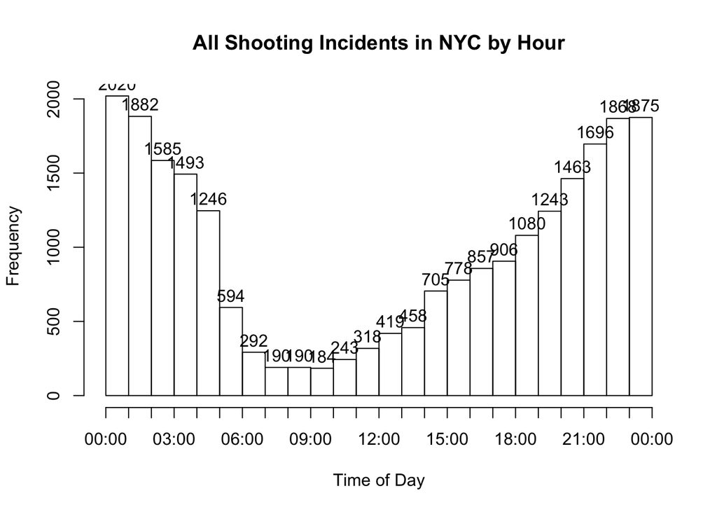

```r
#Visualizing the frequency of all shooting incidents from 2006-2021 by hour
shooting_data$OCCUR_TIME <- as.POSIXct(shooting_data$OCCUR_TIME, format = "%H:%M:%S")
all_incidents <- hist(shooting_data$OCCUR_TIME, "hours", freq = TRUE,
main = "All Shooting Incidents in NYC by Hour",
xlab = "Time of Day", labels = TRUE)
```

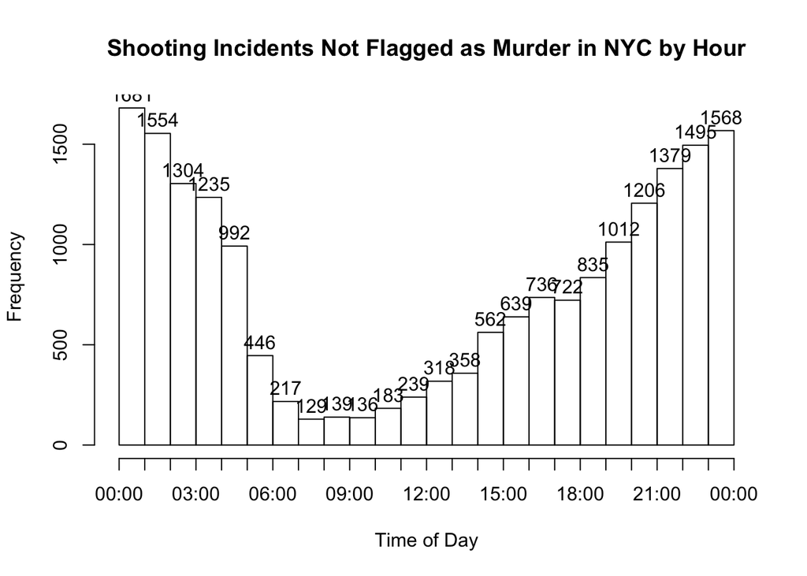

```r
##Visualizing the frequency of all shooting incidents not flagged as murder from 2006-2021 by hour
shootings_no_murder$OCCUR_TIME <- as.POSIXct(shootings_no_murder$OCCUR_TIME, format = "%H:%M:%S")
no_murder <- hist(shootings_no_murder$OCCUR_TIME, "hours", freq = TRUE,
main = "Shooting Incidents Not Flagged as Murder in NYC by Hour",
xlab = "Time of Day", labels = TRUE)
```

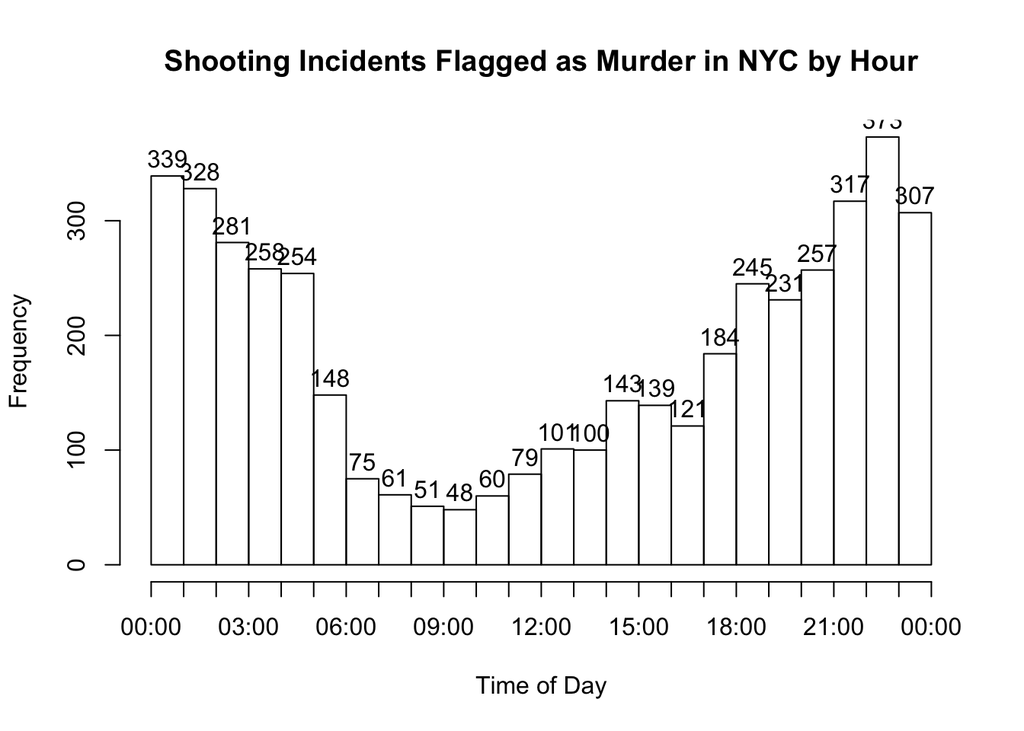

```r
##Visualizing the frequency of all shooting incidents flagged as murder from 2006-2021 by hour
shootings_murder$OCCUR_TIME <- as.POSIXct(shootings_murder$OCCUR_TIME, format = "%H:%M:%S")
murder <- hist(shootings_murder$OCCUR_TIME, "hours", freq = TRUE,
main = "Shooting Incidents Flagged as Murder in NYC by Hour",
xlab = "Time of Day", labels = TRUE)
```

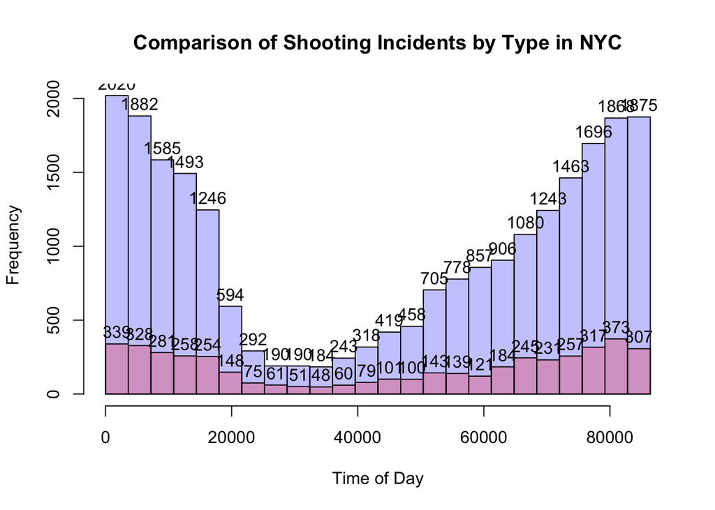

```r
##Overlapping shooting incidents flagged as murder over all shooting incidents in NYC
plot(all_incidents, col = rgb(0,0,1,1/4), labels = TRUE, main = "Comparison of Shooting Incidents by Type in NYC")
plot(murder, col = rgb(1,0,0,1/4), add = T, labels = TRUE)
```

**Analyzing the Data**

```r
##Comparing the number of shooting incidents to shooting incidents flagged as murders in NYC
shooting_data %>%
count(STATISTICAL_MURDER_FLAG == TRUE)
```

| STATISTICAL_MURDER_FLAG == TRUE | n |
| --- | --- |
| FALSE | 19085 |
| TRUE | 4500 |

```r
##Finding the day with the highest amount of shootings in NYC
Mode <- function(x) {
uniqux <- unique(x)
uniqux[which.max(tabulate(match(x, uniqux)))]
}
x <- shooting_data$OCCUR_DATE
result <- Mode(x)
result
```

```
## [1] "07/05/2020"
```

**Modeling Density**

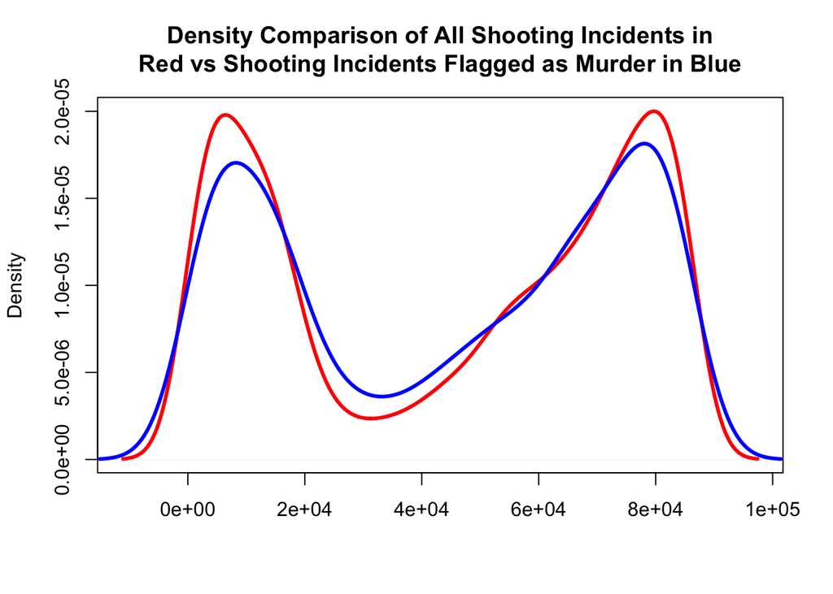

```r
##Modeling density curves for all shooting incidents in NYC vs those flagged as murder
density_all_incidents <- density(as.numeric(shooting_data$OCCUR_TIME))
density_murder <- density(as.numeric(shootings_murder$OCCUR_TIME))
plot(density_all_incidents, lwd = 3, col = "red",
main = "Density Comparison of All Shooting Incidents in
Red vs Shooting Incidents Flagged as Murder in Blue",
xlab = "")
lines(density_murder, col = "blue", lwd = 3)
```

**Conclusion and Bias Identification**

Shooting incidents including those flagged as murder are most active during the hours between 2pm and 6am. The day with the most shooting incidents in this data set is 7/5/2020. A possible source of bias in this report is that it would seem intuitive for shooting incidents to occur more frequently at night since it may be harder to be seen or easier to avoid being caught.Thinking about this for a moment reveals that there are many possible reasons why these hours have more shooting incidents. People are less likely to be working, bars are more likely to be open, and events like rush hour may drive up altercations between individuals leading to shooting incidents. In this project one personal bias I held was that all shooting incidents included in this report were a crime. In reality, several of these shooting incidents could be related to self defense, police shootings and more. Although I did not look at this data in my analysis and differentiate between the type of incident besides those flagged as murder and not, I made sure to keep an open mind at these high numbers for cases not flagged as murder. Some of these shooting instances may have saved lives and prevented further casualties.